# Utilizing Natural Language Processing for Suicidal Ideation Detection in Text

# Problem Statement

According to the American Psychological Association, nearly 20% of teens worldwide have contemplated suicide. Suicidal ideation, the contemplation of taking one's life, can stem from various factors, including psychiatric disorders like anxiety, paranoia, schizophrenia, medication side effects altering hormonal levels, or life events. Life events notably increase the risk of suicidal ideation, such as bullying, relationship endings, loss of a loved one, unemployment, chronic illness, and other triggers. It's essential to acknowledge that these triggers are subjective, with an individual reacting strongly to incidents that others might consider trivial.

The objective of this project is to utilize Natural Language Processing (NLP) to detect potential suicide risks within textual content. With a dataset comprising over fifty thousand classified messages, this classification model holds the potential to significantly enhance the prediction of suicidal ideation, even when not explicitly stated. The mental health field currently lacks machine learning tools, and integrating such models could be invaluable. This particular classification model could play a pivotal role in identifying signs of suicidal thoughts among users of apps or websites. For example, if a user posts content hinting at suicidal thoughts on a platform, this model could recognize the underlying intent and alert professional help, enabling them to offer much-needed support and guidance to the user.

# Importing Libraries

The libraries used here are primarly from Numpy, Pandas, Seaborn, Matplotlib, NLTK and Sklearn. Pickle is also used as a means to save a model for reproducability.

```python
import numpy as np
import pandas as pd
import matplotlib.pyplot as plt
import warnings
warnings.filterwarnings('ignore')

# Visualisation libraries
import matplotlib.pyplot as plt
import seaborn as sns

# Machine Learning Libraries
from sklearn.model_selection import train_test_split,GridSearchCV,RandomizedSearchCV
from sklearn.feature_extraction.text import TfidfVectorizer
from sklearn.feature_selection import SelectKBest,chi2,f_classif
from sklearn.ensemble import RandomForestClassifier,VotingClassifier,AdaBoostClassifier,GradientBoostingClassifier,BaggingClassifier
from sklearn.metrics import classification_report , confusion_matrix
from sklearn.tree import DecisionTreeClassifier
#from xgboost import XGBClassifier
from sklearn.neighbors import KNeighborsClassifier
from sklearn.naive_bayes import GaussianNB, MultinomialNB, BernoulliNB
from skopt import BayesSearchCV
import pickle
import string


# Text Processing libraries
import nltk
from nltk.stem import PorterStemmer
from nltk.tokenize import word_tokenize
from nltk.stem import WordNetLemmatizer
```

# The Data

Source: https://www.kaggle.com/datasets/nikhileswarkomati/suicide-watch

The data comprises of posts scraped from the subreddits r/suicidewatch and r/depression along with the subreddit r/teenagers from Reddit. It consists of a column of text, and expected outcome. The text from r/suicidewatch and r/depression have been classified as "Suicide", and the text from r/teenagers has been classified as "Not Suicide"

```python
df_entire=pd.read_csv(r"C:\Users\nisha\Desktop\JupyterStuff\NLP\data\Suicide_Detection.csv")
#sample of 50K

df=df_entire.sample(n=50000,random_state=11)
```

# Cleaning

The first step in setting up a model is cleaning the data. Firstly, we begin with eliminating non-unique values, and by dropping any null or duplicate values.

```python
#Cleaning
print("Are values unique:",df['Unnamed: 0'].is_unique)
df.drop(columns = 'Unnamed: 0',inplace=True)
print(df.head())
print("Number of null values", df.isnull().sum())
print("Number of duplicate rows", df.duplicated().sum())
```

```
Are values unique: True
                                                     text        class
163086  Rant about my 𝓿𝓮𝓻𝓫𝓪𝓵𝓵𝔂 𝓪𝓫𝓾𝓼𝓲𝓿𝓮 𝓶𝓸𝓽𝓱𝓮𝓻 So this ...  non-suicide
109222  Failed uniFailed uni for the second time, can ...      suicide
180175  whats your favourite book? personally i love 1...  non-suicide
186885  idk if i am the only one but why do i get a lo...  non-suicide
146986  If fish oil comes from fish Then where the fuc...  non-suicide
Number of null values text     0
class    0
dtype: int64
Number of duplicate rows 0
```

# Data Visualisation

Once the data has been cleaned, a simple visualisation to represent the data is done. We can see that there is no class imbalance, as the difference between the number of values of either class is negligible(less than 1%)

A WordCloud is also created for the visual representation of the frequency of words in the sample data.

```
suicide        25033
non-suicide    24967
Name: class, dtype: int64
```

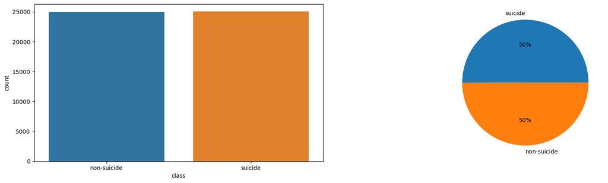

```python
#Visualisation

classCnt = df['class'].value_counts()
print(classCnt)

plt.figure(figsize=((20,5)))

plt.subplot(1,2,1)
sns.countplot(df,x='class')

plt.subplot(1,2,2)
plt.pie(classCnt,labels = classCnt.index,autopct='%.0f%%')

plt.show()
```

```python
#preprocessing part 3
from wordcloud import WordCloud
#removing stopwords
from nltk.corpus import stopwords
stop_words = stopwords.words('english')
df['text'] = df['text'].apply(lambda x: ' '.join([word for word in x.split() if word not in (stop_words)]))
```

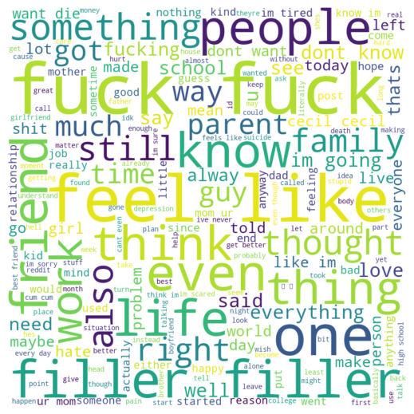

```python
# Generating a WordCloud
wordcloud = WordCloud(width=800, height=800, background_color='white', stopwords=stop_words, min_font_size=10).generate(' '.join(df['text']))

# Display the word cloud using matplotlib
import matplotlib.pyplot as plt
plt.figure(figsize=(5, 5), facecolor=None)
plt.imshow(wordcloud, interpolation="bilinear")
plt.axis("off")
plt.tight_layout(pad=0)

# Show the plot
plt.show()
```

# Data Preprocessing

The next step in preprocessing is to convert the text to lowercase, and to perform tokenization, followed by lemmatization. The stopwords have also been removed.

```python
#preprocessing part 2

#converting all to lower case

df['text']= df['text'].str.lower()

#removing punctuation

df['text'] = df['text'].str.replace(r'[^\w\s]+', '',regex = True)

df.head()
```

[output not shown]

```python
#preprocessing part 3 contd



#lemmatization along with tokenization into words
# Function to perform lemmatization on a given text
def perform_lemmatization(text):
    tokens = word_tokenize(text)  # Tokenize the text into words
    lemmatizer = WordNetLemmatizer()  # Initialize the WordNetLemmatizer
    lemmatized_words = [lemmatizer.lemmatize(word) for word in tokens]  # Lemmatize tokens
    return ' '.join(lemmatized_words)  # Return lemmatized text as a single string

# Apply lemmatization to the 'text' column
df['lemmatized_text'] = df['text'].apply(perform_lemmatization)
df['lemmatized_text'].head()
```

```
163086    rant 𝓿𝓮𝓻𝓫𝓪𝓵𝓵𝔂 𝓪𝓫𝓾𝓼𝓲𝓿𝓮 𝓶𝓸𝓽𝓱𝓮𝓻 probably gon na e...
109222                failed unifailed uni second time kill
180175    whats favourite book personally love 1984 also...
186885    idk one get lot anxiety listen music full volu...
146986    fish oil come fish fuck baby oil come fillerfi...
Name: lemmatized_text, dtype: object
```

```python
#clean data saved to a file

df.to_csv('clean_data.csv')
```

```python
#dfclean1 has all the columns, dfclean has only lemmas + class.
#FINAL PREPROCESSING
dfclean1 = pd.read_csv('clean_data.csv')
dfclean=pd.DataFrame({'text':dfclean1['lemmatized_text'],'class':dfclean1['class']})
dfclean.head()
dfclean.info()
```

```
<class 'pandas.core.frame.DataFrame'>
RangeIndex: 50000 entries, 0 to 49999
Data columns (total 2 columns):
 #   Column  Non-Null Count  Dtype
---  ------  --------------  -----
 0   text    49991 non-null  object
 1   class   50000 non-null  object
dtypes: object(2)
memory usage: 781.4+ KB
```

```python
#removing the two null values(found in index 435 and 1290)
ind = dfclean[dfclean['text'].isnull()].index
dfclean.dropna(inplace=True)
ind = dfclean[dfclean['text'].isnull()].index
print(ind)
```

```
Int64Index([], dtype='int64')
```

Once the data is clean and fully ready, we begin setting up the model

# The Model

```python
#finally, the machine learning
#setting things up
x,y = dfclean['text'],dfclean['class']
x.shape
```

```
(49991,)
```

```python
vectorizer = TfidfVectorizer(min_df=50,max_features=5000)
x =  vectorizer.fit_transform(x)
# Save the model
with open('tfidf.pkl', 'wb') as f:
    pickle.dump(vectorizer, f)
```

The data is split into training, validation and testing data.

```python
#double split
X_train, X_test, y_train, y_test = train_test_split(x, y, test_size=0.2, random_state=42)
X_train_split, X_val, y_train_split, y_val = train_test_split(X_train, y_train, test_size=0.2, random_state=22)
```

```python
#obtained through GridSearch
param_grid = {
    'n_estimators': [4, 5],
    'criterion': ['entropy'],
    'max_depth': (1, 4),
    'min_samples_split': (2, 5)
}
base_estimator_ada = DecisionTreeClassifier(max_depth=1)

# Create AdaBoost classifier
ada_boost = AdaBoostClassifier(base_estimator=base_estimator_ada, n_estimators=50, random_state=42)
ada_boost.fit(X_train_split, y_train_split)


train_accuracy = ada_boost.score(X_train_split, y_train_split)

val_accuracy = ada_boost.score(X_val, y_val)

test_accuracy = ada_boost.score(X_test, y_test)

# Print accuracies
print('Training accuracy (AdaBoost):', train_accuracy)
print('Validation accuracy (AdaBoost):', val_accuracy)
print('Testing accuracy (AdaBoost):', test_accuracy)

# Save the AdaBoost model using pickle if needed
with open('adaboost_classifier.pkl', 'wb') as f:
    pickle.dump(ada_boost, f)
```

```
Training accuracy (AdaBoost): 0.8829744006501422
Validation accuracy (AdaBoost): 0.8748593574196775
Testing accuracy (AdaBoost): 0.8798879887988799
```

# Results

The final testing accuracy manages to settle at around 88%

A Confusion Matrix is also created to visualise the results of the prediction on the testing set.

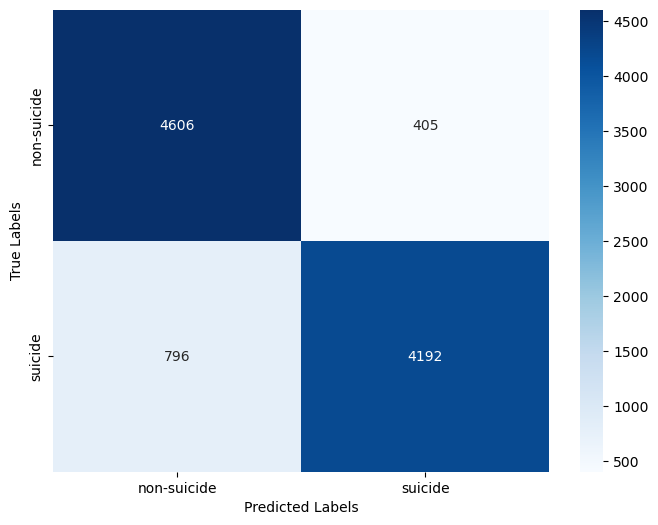

```python
y_pred = ada_boost.predict(X_test)
# Generate the confusion matrix
conf_matrix = confusion_matrix(y_test, y_pred)

# Plotting the confusion matrix
plt.figure(figsize=(8, 6))
sns.heatmap(conf_matrix, annot=True, cmap='Blues', fmt='d',
            xticklabels=ada_boost.classes_,
            yticklabels=ada_boost.classes_)
plt.xlabel('Predicted Labels')
plt.ylabel('True Labels')
plt.show()
```

Finally, we identify the values of the accuracy, precision, recall and specificity of the prediction.

```python
from sklearn.metrics import confusion_matrix, precision_score, recall_score, accuracy_score

#Accuracy-indicating the proportion of correctly predicted samples among the total samples.(all correct/total)
accuracy = accuracy_score(y_test, y_pred)

#Precision-proportion of correctly predicted positive samples among all samples predicted as positive.(correct pos/all pred pos)
precision = precision_score(y_test, y_pred, pos_label='suicide')

#Recall-proportion of correctly predicted positive samples among all actual positive samples.(correct pos/all actual pos)
recall = recall_score(y_test, y_pred, pos_label='suicide')

# Specificity-proportion of correctly predicted negative samples among all actual negative samples.(correct neg/all actual negs)
specificity = conf_matrix[0, 0] / (conf_matrix[0, 0] + conf_matrix[0, 1])
print(f'Accuracy: {accuracy*100}')
print(f'Precision: {precision*100}')
print(f'Recall (Sensitivity): {recall*100}')
print(f'Specificity: {specificity*100}')
```

```
Accuracy: 87.98879887988798
Precision: 91.18990646073526
Recall (Sensitivity): 84.04170008019246
Specificity: 91.91778088205947
```

# Testing

A test on a sample text has been conducted.

```python
def perform_lemmatization2(text):
    lemmatizer = WordNetLemmatizer()
    lemmatized_text = [lemmatizer.lemmatize(word) for word in text]
    return ' '.join(lemmatized_text)
```

```python
def preprocess(inp):
    inp = inp.lower() #convert to lower case
    inp = inp.replace(r'[^\w\s]+', '') #remove punctuations
    inp = [word for word in inp.split() if word not in (stop_words)] #tokenize the sentence
    inp = perform_lemmatization2(inp)
    inputToModel = vectorizer.transform([inp]).toarray() #transform to vector form
    return inputToModel
```

```python
def check(input_text):
    # Define the input text box
    print('Input : ',input_text) #take input from user
    processed_array = preprocess(input_text) #preprocess the text
    predict = ada_boost.predict(processed_array) #Model prediction
    print('Output : ', predict[0])
```

```python
check("I don't know what else to say.idk how to take my life I just wish I would get hit by a car or be in the wrong place at the wrong time something")
```

```
Input :  I don't know what else to say.idk how to take my life I just wish I would get hit by a car or be in the wrong place at the wrong time something
Output :  suicide
```

The model has classified the text above as containing suicidal ideation.